# Learning Network Analysis

# Notes on Network Analysis

```r
# Install Packages
# install.packages("igraph")
# install.packages("network")
# install.packages("sna")
# install.packages("visNetwork")
# install.packages("ndtv", dependencies=T)
# install.packages("RColorBrewer")
# install.packages("extrafont")
# install.packages("png")
# install.packages("animation")
# install.packages("maps")
# install.packages("geosphere")
library(dplyr)
```

### One mode network dataset

```r
# Load data sample 1 (data frame)
nodes <- read.csv("Data files/Dataset1-Media-Example-NODES.csv", header=T, as.is=T)
links <- read.csv("Data files/Dataset1-Media-Example-EDGES.csv", header=T, as.is=T)
```

```r
# Preview the data structure
head(nodes)
```

|  | id | media | media.type | type.label | audience.size |
| --- | --- | --- | --- | --- | --- |
| 1 | s01 | NY Times | 1 | Newspaper | 20 |
| 2 | s02 | Washington Post | 1 | Newspaper | 25 |
| 3 | s03 | Wall Street Journal | 1 | Newspaper | 30 |
| 4 | s04 | USA Today | 1 | Newspaper | 32 |
| 5 | s05 | LA Times | 1 | Newspaper | 20 |
| 6 | s06 | New York Post | 1 | Newspaper | 50 |

```r
head(links)
```

|  | from | to | weight | type |
| --- | --- | --- | --- | --- |
| 1 | s01 | s02 | 10 | hyperlink |
| 2 | s01 | s02 | 12 | hyperlink |
| 3 | s01 | s03 | 22 | hyperlink |
| 4 | s01 | s04 | 21 | hyperlink |
| 5 | s04 | s11 | 22 | mention |
| 6 | s05 | s15 | 21 | mention |

```r
# The number of nodes and links is the grain for the two data frames; hence aggregation is needed if rows are not unique
# nrow(nodes); length(unique(nodes$id))
# nrow(links); nrow(unique(links[,c("from", "to")]))
```

Notice that in data sample 1, the links are among nodes within one group. This type of data set examines the relationships among one group of entities. Also, the links are directional, meaning the data set will allow links between two nodes from opposite directions.

```r
# Collapse multiple links of the same type between the same two nodes
# by summing their weights, using aggregate() by "from", "to", & "type":
links <- aggregate(links[,3], by = links[,-3], FUN = sum) # aggregate "weight" by "from", "to", "mention"
links <- links[order(links$from, links$to),]
colnames(links)[4] <- "weight"
rownames(links) <- NULL # Otherwise the ordered index would be the row names by default
```

For this kind of dataset, one has to make sure that:

- Both nodes and links are stored in a data frame
- The nodes (entities) and the links (“from” + “to”) are unique
- Nodes and links should have matching ID (keys)
- Both nodes and links can have extra features such as type (categorical) and size/weight (continuous) as modifiers

```r
# Load data sample 2 (matrix)
nodes2 <- read.csv("./Data files/Dataset2-Media-User-Example-NODES.csv", header=T, as.is=T)
links2 <- read.csv("./Data files/Dataset2-Media-User-Example-EDGES.csv", header=T, row.names=1)
head(nodes2)
```

|  | id | media | media.type | media.name | audience.size |
| --- | --- | --- | --- | --- | --- |
| 1 | s01 | NYT | 1 | Newspaper | 20 |
| 2 | s02 | WaPo | 1 | Newspaper | 25 |
| 3 | s03 | WSJ | 1 | Newspaper | 30 |
| 4 | s04 | USAT | 1 | Newspaper | 32 |
| 5 | s05 | LATimes | 1 | Newspaper | 20 |
| 6 | s06 | CNN | 2 | TV | 56 |

```r
head(links2)
```

|  | U01 | U02 | U03 | U04 | U05 | U06 | U07 | U08 | U09 | U10 | U11 | U12 | U13 | U14 | U15 | U16 | U17 | U18 | U19 | U20 |
| --- | --- | --- | --- | --- | --- | --- | --- | --- | --- | --- | --- | --- | --- | --- | --- | --- | --- | --- | --- | --- |
| s01 | 1 | 1 | 1 | 0 | 0 | 0 | 0 | 0 | 0 | 0 | 0 | 0 | 0 | 0 | 0 | 0 | 0 | 0 | 0 | 0 |
| s02 | 0 | 0 | 0 | 1 | 1 | 0 | 0 | 0 | 0 | 0 | 0 | 0 | 0 | 0 | 0 | 0 | 0 | 0 | 0 | 1 |
| s03 | 0 | 0 | 0 | 0 | 0 | 1 | 1 | 1 | 1 | 0 | 0 | 0 | 0 | 0 | 0 | 0 | 0 | 0 | 0 | 0 |
| s04 | 0 | 0 | 0 | 0 | 0 | 0 | 0 | 0 | 1 | 1 | 1 | 0 | 0 | 0 | 0 | 0 | 0 | 0 | 0 | 0 |
| s05 | 0 | 0 | 0 | 0 | 0 | 0 | 0 | 0 | 0 | 0 | 1 | 1 | 1 | 0 | 0 | 0 | 0 | 0 | 0 | 0 |
| s06 | 0 | 0 | 0 | 0 | 0 | 0 | 0 | 0 | 0 | 0 | 0 | 0 | 1 | 1 | 0 | 0 | 1 | 0 | 0 | 0 |

```r
# Transfer links2 into a matrix
links2 <- as.matrix(links2)
dim(links2)
```

```
[1] 10 20
```

```r
dim(nodes2)
```

```
[1] 30  5
```

We can see that links2 is an adjacency matrix for a two-mode network. Two-mode or bipartite graphs have two different types of actors and links that go across, but not within each type. Our second media example is a network of that kind, examining links between news sources and their consumers.

For this kind of dataset, one has to make sure that:

- Nodes dataset is still a data frame, while links dataset should be a matrix
- The unique count of entities in nodes equals number of rows and columns in links (number of entities in group A + group B)
- Nodes and links have matching keys

After setting up the dataset, we can start plotting the graphs using the “igraph” package. First we need to converting the data to an igraph object:

- The **graph_from_data_frame()** function takes two data frames: ‘d’ and ‘vertices’.
  - ‘d’ describes the edges of the network - it should start with two columns containing the source and target node IDs for each network tie
  - ‘vertices’ should start with a column of node IDs
  - any additional columns in either data frame are interpreted as attributes.

```r
# Create a igraph object
library(igraph)
net <- graph_from_data_frame(d=links, vertices=nodes, directed=T)
class(net) # Check the class
```

```
[1] "igraph"
```

```r
E(net)
```

```
+ 49/49 edges (vertex names):
 [1] s01->s02 s01->s03 s01->s04 s01->s15 s02->s01 s02->s03 s02->s09 s02->s10 s03->s01 s03->s04 s03->s05
[12] s03->s08 s03->s10 s03->s11 s03->s12 s04->s03 s04->s06 s04->s11 s04->s12 s04->s17 s05->s01 s05->s02
[23] s05->s09 s05->s15 s06->s06 s06->s16 s06->s17 s07->s03 s07->s08 s07->s10 s07->s14 s08->s03 s08->s07
[34] s08->s09 s09->s10 s10->s03 s12->s06 s12->s13 s12->s14 s13->s12 s13->s17 s14->s11 s14->s13 s15->s01
[45] s15->s04 s15->s06 s16->s06 s16->s17 s17->s04
```

```r
V(net)
```

```
+ 17/17 vertices, named:
 [1] s01 s02 s03 s04 s05 s06 s07 s08 s09 s10 s11 s12 s13 s14 s15 s16 s17
```

```r
E(net)$type
```

```
 [1] "hyperlink" "hyperlink" "hyperlink" "mention"   "hyperlink" "hyperlink" "hyperlink" "hyperlink"
 [9] "hyperlink" "hyperlink" "hyperlink" "hyperlink" "mention"   "hyperlink" "hyperlink" "hyperlink"
[17] "mention"   "mention"   "hyperlink" "mention"   "mention"   "hyperlink" "hyperlink" "mention"
[25] "hyperlink" "hyperlink" "mention"   "mention"   "mention"   "hyperlink" "mention"   "hyperlink"
[33] "mention"   "mention"   "mention"   "hyperlink" "mention"   "hyperlink" "mention"   "hyperlink"
[41] "mention"   "mention"   "mention"   "hyperlink" "hyperlink" "hyperlink" "hyperlink" "mention"
[49] "hyperlink"
```

```r
V(net)$media
```

```
 [1] "NY Times"            "Washington Post"     "Wall Street Journal" "USA Today"
 [5] "LA Times"            "New York Post"       "CNN"                 "MSNBC"
 [9] "FOX News"            "ABC"                 "BBC"                 "Yahoo News"
[13] "Google News"         "Reuters.com"         "NYTimes.com"         "WashingtonPost.com"
[17] "AOL.com"
```

For the data sample 2, we need to use another function from the igraph package, i.e. **graph_from_incidence_matrix()**.

```r
net2 <- graph_from_incidence_matrix(links2)
```

After creating the igraph object, we can plot it.

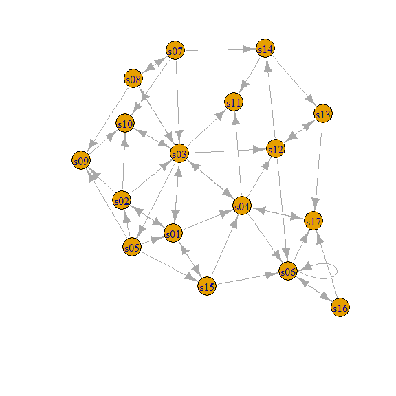

```r
plot(net) # Raw graph
```